# Storm Cosequence

Marco Venturi

2022-07-01

## Synopsis

This report study the differencies between all US countries about how much it cost different category of storm events and how much fatalities those events cause.  
The questions that i tried to answer are :

1. Across the United States, which types of events are most harmful with respect to population health?

2.Across the United States, which types of events have the greatest economic consequences?

In the firt answer i decide to analize *FATALITIES* and *EVTTYPE*, because i thought that the worst case is the case with more *FATALITIES*instead of *INJURIES*.

In the second answer i decide to analize *CROPDMG* and *PROPDMG* for understand how much it cost differents types over different costs.

## Reading Data

The zip folder was unziped using R.utils library, in specific *bunzip2()* function, where the output csv file is called as is folder, *repdata_data_StormData.csv* , then the new file was read with *read.csv* function.

```r
#New csv file is create inside data folder
library(R.utils)
```

```r
library(ggplot2)

bunzip2("./data/repdata_data_StormData.csv.bz2", "repdata_data_StormData.csv", remove = FALSE, skip = TRUE)
```

```
## [1] "repdata_data_StormData.csv"
## attr(,"temporary")
## [1] FALSE
```

```r
df <- read.csv("./data/repdata_data_StormData.csv")
```

## Data Processing

### 1) which types of events are most harmful with respect to population health?

The first question was answered by sum all *FATALITIES* divide by *EVTTYPE* and adding a column to this new data set for checking if there where any Unknow events, this was possible by checking unique values of *EVTTYPE*, because if the event is not Know the *EVTTYPE* is describe as *“^SummarY* ” (regex)**.

```r
sum_fatalites_over_evtype <- aggregate(FATALITIES ~ EVTYPE, df, FUN = sum)

sum_fatalites_over_evtype$know_event <- sapply(sum_fatalites_over_evtype$EVTYPE, function(x){

  if(grepl("^Summary*", x)){
    result <- "Unknow Event"
  }else{
    result <- "Know Event"
  }
  return(result)

})
```

In the end i decide to order the data set for plot just the first 10th event over 985 types

```r
sum_fatalites_over_evtype <- sum_fatalites_over_evtype[order(sum_fatalites_over_evtype$FATALITIES , decreasing = TRUE),]

head(sum_fatalites_over_evtype ,10)
```

```
##             EVTYPE FATALITIES know_event
## 834        TORNADO       5633 Know Event
## 130 EXCESSIVE HEAT       1903 Know Event
## 153    FLASH FLOOD        978 Know Event
## 275           HEAT        937 Know Event
## 464      LIGHTNING        816 Know Event
## 856      TSTM WIND        504 Know Event
## 170          FLOOD        470 Know Event
## 585    RIP CURRENT        368 Know Event
## 359      HIGH WIND        248 Know Event
## 19       AVALANCHE        224 Know Event
```

### 2) which types of events have the greatest economic consequences?

The second question was answered by sum all *CROPDMG* and *PROPDMG* divide by *EVTTYPE* and adding a column to this new data set for checking if there where any Unknow events, this was possible by checking unique values of *EVTTYPE*, because if the event is not Know the *EVTTYPE* is describe as *“^SummarY* ” (regex)**.

```r
sum_damage <- aggregate(CROPDMG + PROPDMG ~ EVTYPE, df, sum )

head(sum_damage)
```

```
##                  EVTYPE CROPDMG + PROPDMG
## 1    HIGH SURF ADVISORY               200
## 2         COASTAL FLOOD                 0
## 3           FLASH FLOOD                50
## 4             LIGHTNING                 0
## 5             TSTM WIND               108
## 6       TSTM WIND (G45)                 8
```

```r
sum_damage$know_event <- sapply(sum_damage$EVTYPE, function(x){

  if(grepl("^Summary*", x)){
    result <- "Unknow Event"
  }else{
    result <- "Know Event"
  }
  return(result)

})
```

In the end i decide to order the data set for plot just the first 10th event over 985 types

```r
sum_damage <- sum_damage[order(sum_damage$`CROPDMG + PROPDMG` , decreasing = TRUE),]

head(sum_damage, 10)
```

```
##                 EVTYPE CROPDMG + PROPDMG know_event
## 834            TORNADO         3312276.7 Know Event
## 153        FLASH FLOOD         1599325.1 Know Event
## 856          TSTM WIND         1445168.2 Know Event
## 244               HAIL         1268289.7 Know Event
## 170              FLOOD         1067976.4 Know Event
## 760  THUNDERSTORM WIND          943635.6 Know Event
## 464          LIGHTNING          606932.4 Know Event
## 786 THUNDERSTORM WINDS          464978.1 Know Event
## 359          HIGH WIND          342014.8 Know Event
## 972       WINTER STORM          134699.6 Know Event
```

## Results

### 1)Across the United States, which types of events (as indicated in the EVTYPE variable) are most harmful with respect to population health?

Tornado seems to be the most dangearous event across all country, while other event under the 5TH are less dangeorus with around hundreds of deads

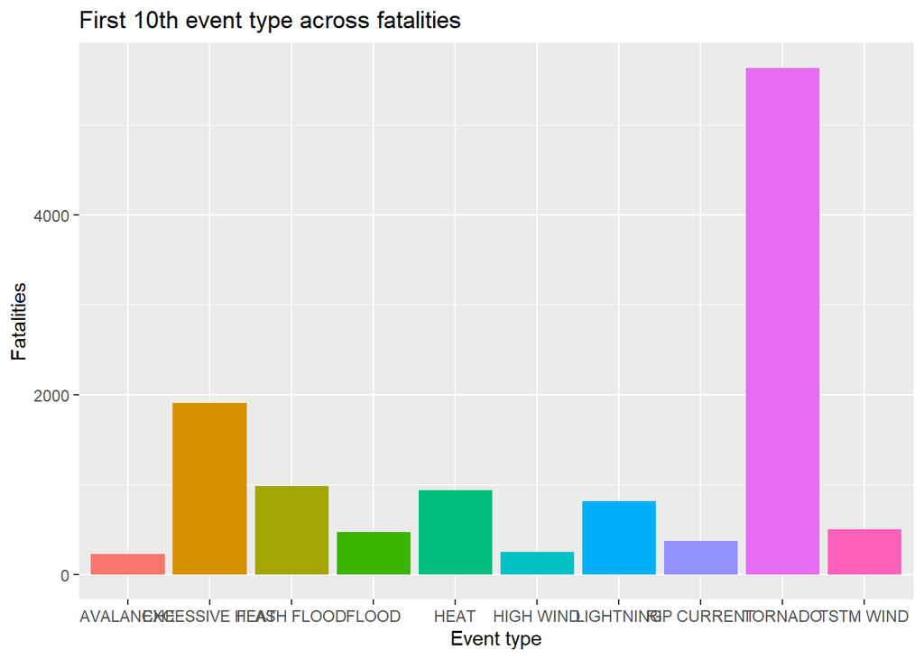

```r
ggplot(sum_fatalites_over_evtype[1:10, ], aes(y = FATALITIES, x = EVTYPE )) +
  geom_bar(stat = "identity",aes( fill = factor(EVTYPE))) +
  ggtitle("First 10th event type across fatalities") +
  labs(x="Event type", y="Fatalities") +
  guides(fill = "none")
```

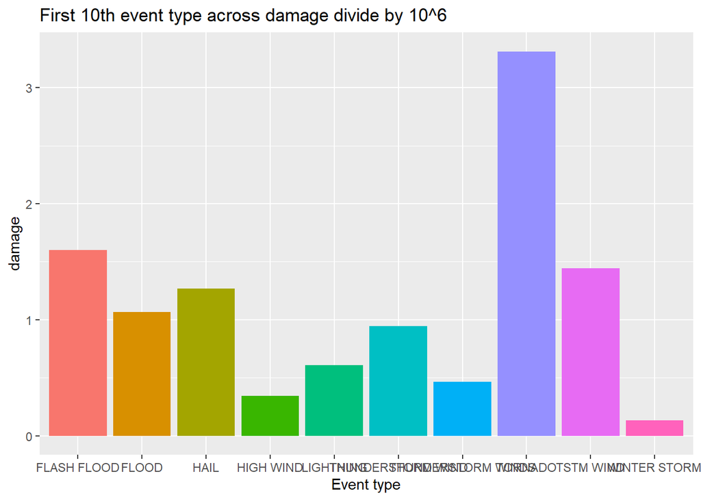

```r
ggplot(sum_damage[1:10, ], aes(y = `CROPDMG + PROPDMG`/10^6, x = EVTYPE )) +
  geom_bar(stat = "identity",aes( fill = factor(EVTYPE))) +
  ggtitle("First 10th event type across damage divide by 10^6") +
  labs(x="Event type", y="damage") +
  guides(fill = "none")
```